# Applied stats cw

## Initial Analysis

Read in the data

```r
dat<- read.csv("S2_attributes_anonymous.csv",header=TRUE)
```

Check the structure of the data and the correlation between the variables

```r
str(dat)
```

```
## 'data.frame':    797 obs. of  24 variables:
##  $ random      : int  3 8 63 64 66 71 83 85 96 100 ...
##  $ sbcountry   : int  NA 1 21 35 1 31 NA 35 1 1 ...
##  $ snat        : int  NA 1 21 35 1 21 NA 35 1 1 ...
##  $ byear       : int  NA 1953 1961 1982 1970 1953 NA 1964 1972 1975 ...
##  $ cyear       : int  NA 2003 2002 2001 2003 2002 NA 2001 2002 2002 ...
##  $ tyear       : int  NA 2003 2002 2002 2003 2002 NA 2002 2003 2002 ...
##  $ ryear       : int  NA 2005 2004 2003 2004 2004 NA 2007 2005 2003 ...
##  $ health      : int  NA 2 6 3 3 6 NA 4 6 6 ...
##  $ recom       : int  NA 6 6 1 1 1 NA 6 4 1 ...
##  $ risk        : int  NA 3 3 0 1 1 NA 3 2 0 ...
##  $ drisk       : int  NA 1 3 0 1 1 NA 3 1 0 ...
##  $ intel       : int  NA 4 4 0 1 1 NA 4 1 0 ...
##  $ ecstat      : int  NA 1 1 NA 1 9 NA 1 1 NA ...
##  $ vtf         : int  NA 0 0 0 0 0 NA 0 1 0 ...
##  $ rdi         : int  NA NA NA NA NA NA NA 35 NA NA ...
##  $ assault     : int  NA NA NA NA NA NA NA 2 NA NA ...
##  $ ape         : int  NA 6 NA NA NA NA NA 10 4 0 ...
##  $ sccountry   : int  NA 1 32 1 1 32 NA 32 1 1 ...
##  $ preape      : int  NA 1 0 3 3 3 NA NA 12 NA ...
##  $ saffiliation: int  NA 0 1 1 1 1 NA 1 1 NA ...
##  $ ublbg       : int  NA 0 2 0 0 1 NA 1 0 NA ...
##  $ rft         : int  NA 9 0 1 9 1 NA NA 1 NA ...
##  $ outdeg      : int  0 3 0 0 0 0 0 5 1 0 ...
##  $ indeg       : int  1 1 1 0 0 0 0 12 2 0 ...
```

```r
summary(dat)
```

```
##      random       sbcountry          snat           byear
##  Min.   :   3   Min.   : 1.00   Min.   : 1.00   Min.   :1913
##  1st Qu.:2512   1st Qu.: 1.00   1st Qu.: 1.00   1st Qu.:1969
##  Median :5034   Median :32.00   Median :32.00   Median :1975
##  Mean   :4994   Mean   :23.92   Mean   :23.73   Mean   :1973
##  3rd Qu.:7349   3rd Qu.:35.00   3rd Qu.:35.00   3rd Qu.:1979
##  Max.   :9992   Max.   :52.00   Max.   :50.00   Max.   :1988
##                 NA's   :31      NA's   :27      NA's   :34
##      cyear          tyear          ryear          health
##  Min.   :2001   Min.   :2001   Min.   :2002   Min.   :1.00
##  1st Qu.:2001   1st Qu.:2002   1st Qu.:2004   1st Qu.:3.00
##  Median :2001   Median :2002   Median :2005   Median :4.00
##  Mean   :2002   Mean   :2002   Mean   :2005   Mean   :4.31
##  3rd Qu.:2002   3rd Qu.:2002   3rd Qu.:2007   3rd Qu.:6.00
##  Max.   :2007   Max.   :2007   Max.   :2009   Max.   :7.00
##  NA's   :188    NA's   :106    NA's   :32     NA's   :59
##      recom            risk           drisk           intel
##  Min.   :0.000   Min.   :0.000   Min.   :0.000   Min.   :0.000
##  1st Qu.:4.000   1st Qu.:2.000   1st Qu.:1.000   1st Qu.:1.000
##  Median :6.000   Median :2.000   Median :1.000   Median :3.000
##  Mean   :4.632   Mean   :2.101   Mean   :1.576   Mean   :2.269
##  3rd Qu.:6.000   3rd Qu.:3.000   3rd Qu.:3.000   3rd Qu.:3.000
##  Max.   :9.000   Max.   :6.000   Max.   :3.000   Max.   :7.000
##  NA's   :52      NA's   :43      NA's   :195     NA's   :64
##      ecstat           vtf              rdi            assault
##  Min.   :0.000   Min.   :0.0000   Min.   :  0.00   Min.   :  0.000
##  1st Qu.:1.000   1st Qu.:0.0000   1st Qu.: 16.00   1st Qu.:  1.000
##  Median :1.000   Median :0.0000   Median : 31.00   Median :  3.000
##  Mean   :1.075   Mean   :0.1076   Mean   : 49.86   Mean   :  8.945
##  3rd Qu.:1.000   3rd Qu.:0.0000   3rd Qu.: 64.00   3rd Qu.:  9.000
##  Max.   :9.000   Max.   :3.0000   Max.   :456.00   Max.   :153.000
##  NA's   :249     NA's   :193      NA's   :479      NA's   :507
##       ape           sccountry         preape        saffiliation
##  Min.   : 0.000   Min.   : 1.00   Min.   : 0.000   Min.   :0.000
##  1st Qu.: 2.000   1st Qu.: 1.00   1st Qu.: 1.000   1st Qu.:1.000
##  Median : 5.000   Median : 1.00   Median : 2.000   Median :1.000
##  Mean   : 5.679   Mean   :16.03   Mean   : 2.571   Mean   :1.569
##  3rd Qu.: 8.000   3rd Qu.:32.00   3rd Qu.: 3.000   3rd Qu.:2.000
##  Max.   :34.000   Max.   :58.00   Max.   :20.000   Max.   :5.000
##  NA's   :246      NA's   :76      NA's   :200      NA's   :57
##      ublbg             rft            outdeg            indeg
##  Min.   :0.0000   Min.   :0.000   Min.   :  0.000   Min.   : 0.000
##  1st Qu.:0.0000   1st Qu.:1.000   1st Qu.:  0.000   1st Qu.: 0.000
##  Median :0.0000   Median :1.000   Median :  0.000   Median : 1.000
##  Mean   :0.3655   Mean   :1.563   Mean   :  1.882   Mean   : 1.882
##  3rd Qu.:1.0000   3rd Qu.:1.000   3rd Qu.:  1.000   3rd Qu.: 3.000
##  Max.   :2.0000   Max.   :9.000   Max.   :123.000   Max.   :21.000
##  NA's   :83       NA's   :110
```

```r
round(cor(dat[,(1:ncol(dat))],use="pairwise.complete" ) ,2)
```

```
##              random sbcountry  snat byear cyear tyear ryear health recom
## random         1.00      0.04  0.03  0.04 -0.04  0.02  0.03   0.06  0.06
## sbcountry      0.04      1.00  0.96  0.28 -0.34 -0.16  0.36   0.12  0.35
## snat           0.03      0.96  1.00  0.28 -0.35 -0.16  0.37   0.14  0.37
## byear          0.04      0.28  0.28  1.00 -0.29 -0.12  0.03   0.21  0.09
## cyear         -0.04     -0.34 -0.35 -0.29  1.00  0.67  0.03  -0.08 -0.07
## tyear          0.02     -0.16 -0.16 -0.12  0.67  1.00  0.11   0.02  0.02
## ryear          0.03      0.36  0.37  0.03  0.03  0.11  1.00   0.15  0.68
## health         0.06      0.12  0.14  0.21 -0.08  0.02  0.15   1.00  0.18
## recom          0.06      0.35  0.37  0.09 -0.07  0.02  0.68   0.18  1.00
## risk           0.04      0.30  0.31  0.02  0.06  0.15  0.67   0.18  0.75
## drisk          0.03      0.33  0.33  0.08 -0.08  0.01  0.56   0.04  0.53
## intel          0.03      0.26  0.27 -0.08  0.15  0.19  0.67   0.14  0.64
## ecstat        -0.03     -0.07 -0.08 -0.03  0.00  0.04 -0.10   0.10 -0.22
## vtf            0.02      0.08  0.08  0.06 -0.14 -0.07 -0.02  -0.20  0.06
## rdi            0.13      0.22  0.20  0.06 -0.10 -0.11  0.28  -0.10  0.03
## assault        0.12      0.17  0.17 -0.02 -0.10 -0.10  0.17  -0.09 -0.01
## ape            0.04      0.19  0.19 -0.10  0.11  0.12  0.63   0.04  0.54
## sccountry      0.03      0.37  0.37  0.05 -0.03  0.07  0.36   0.23  0.31
## preape         0.03      0.12  0.10  0.04 -0.04  0.02  0.04   0.03  0.06
## saffiliation  -0.01      0.14  0.15  0.02  0.05  0.02  0.06  -0.03  0.11
## ublbg         -0.01      0.26  0.26  0.04 -0.12 -0.07  0.11   0.02  0.12
## rft           -0.03     -0.08 -0.06  0.07  0.01 -0.01  0.00   0.03 -0.02
## outdeg         0.04      0.11  0.12 -0.01  0.04  0.17  0.19   0.04  0.18
## indeg          0.03      0.32  0.34  0.03 -0.05  0.10  0.60   0.12  0.39
##               risk drisk intel ecstat   vtf   rdi assault   ape sccountry
## random        0.04  0.03  0.03  -0.03  0.02  0.13    0.12  0.04      0.03
## sbcountry     0.30  0.33  0.26  -0.07  0.08  0.22    0.17  0.19      0.37
## snat          0.31  0.33  0.27  -0.08  0.08  0.20    0.17  0.19      0.37
## byear         0.02  0.08 -0.08  -0.03  0.06  0.06   -0.02 -0.10      0.05
## cyear         0.06 -0.08  0.15   0.00 -0.14 -0.10   -0.10  0.11     -0.03
## tyear         0.15  0.01  0.19   0.04 -0.07 -0.11   -0.10  0.12      0.07
## ryear         0.67  0.56  0.67  -0.10 -0.02  0.28    0.17  0.63      0.36
## health        0.18  0.04  0.14   0.10 -0.20 -0.10   -0.09  0.04      0.23
## recom         0.75  0.53  0.64  -0.22  0.06  0.03   -0.01  0.54      0.31
## risk          1.00  0.64  0.79  -0.20 -0.01  0.21    0.13  0.62      0.34
## drisk         0.64  1.00  0.54  -0.08  0.14  0.50    0.37  0.38      0.33
## intel         0.79  0.54  1.00  -0.14 -0.06  0.06    0.01  0.66      0.36
## ecstat       -0.20 -0.08 -0.14   1.00 -0.01  0.07    0.04  0.16      0.03
## vtf          -0.01  0.14 -0.06  -0.01  1.00  0.01    0.06 -0.12      0.08
```

[output cut: 20 more lines]

```
## risk           0.06         0.09  0.10 -0.06   0.15  0.45
## drisk          0.04         0.01  0.18 -0.08   0.05  0.33
## intel          0.03         0.10  0.09 -0.06   0.22  0.50
## ecstat         0.07        -0.06 -0.01 -0.03  -0.02 -0.07
## vtf            0.00        -0.04  0.05  0.01   0.05  0.02
## rdi           -0.09         0.01 -0.02  0.03   0.00  0.21
## assault       -0.06        -0.01  0.00  0.00   0.00  0.11
## ape            0.08         0.12  0.04 -0.02   0.18  0.44
## sccountry     -0.08        -0.05  0.23 -0.05   0.10  0.27
## preape         1.00         0.08  0.16 -0.04  -0.02  0.00
## saffiliation   0.08         1.00 -0.08 -0.06   0.02  0.03
## ublbg          0.16        -0.08  1.00 -0.11   0.06  0.07
## rft           -0.04        -0.06 -0.11  1.00  -0.04  0.05
## outdeg        -0.02         0.02  0.06 -0.04   1.00  0.31
## indeg          0.00         0.03  0.07  0.05   0.31  1.00
```

Note that *ape*, *drisk*, *cyear*, *sbcountrt* are strongly correalated with other variables.

Convert some of the variables into factors and simplify them.

```r
dat$recom[dat$recom != 6] <-1
dat$recom[dat$recom == 6] <-0
dat$recom<-factor(dat$recom,levels=0:1,labels=c("Stay", "Release"))

dat$age = dat$tyear - dat$byear

dat$tage = dat$tyear - dat$byear
dat$tage <-cut(dat$tage, breaks=c(0,18,59,89))
dat$tage <- factor(as.numeric(dat$tage), levels=1:3, labels=c("Children", "Adults", "Seniors"))

dat$detlength = dat$ryear- dat$tyear+1

dat$health[dat$health==1] = 0
dat$health[dat$health>1] = 1
dat$health<-factor(dat$health,levels=c(0,1),labels=c("Bad health", "Not bad health"))

dat$saffiliation[dat$saffiliation==3]<-1
dat$saffiliation[dat$saffiliation==4]<-3
dat$saffiliation[dat$saffiliation==5]<-0
dat$saffiliation <-factor(dat$saffiliation,levels=0:3,labels=c("No Affiliation", "AQ", "TB", "Other"))

dat$intel[dat$intel==3]<-2
dat$intel[dat$intel==4]<-3
dat$intel[dat$intel==7]<-0
dat$intel<-factor(dat$intel, levels=0:3,labels=c("No Intel", "Low", "Medium", "High"))

dat$ublbg = factor(dat$ublbg, levels = 0:2, labels = c("Low", "Medium", "High"))

dat$risk = factor(dat$risk, levels = 0:3, labels = c("No", "Low", "Medium", "High"))
dat$drisk = factor(dat$drisk, levels = 0:3, labels = c("No", "Low", "Medium", "High"))

dat$ecstat[dat$ecstat ==9] <- 2
dat$ecstat = factor(dat$ecstat, levels = 0:2, labels = c("No", "Yes", "Not clear"))

dat$rft[dat$rft==8] <- 3
dat$rft[dat$rft==9] <- 4
dat$rft = factor(dat$rft, levels = 0:4, labels = c("No Recorded Reason", "To Provide Information", "Prosecution", "Affiliation With TB/AQ", "Membership in AQ"))

colnames(dat)[14] = 'hungerstrike'
dat$hungerstrike[dat$hungerstrike > 0] <- 1
dat$hungerstrike = factor(dat$hungerstrike, levels = 0:1, labels = c("No","Yes"))

dat$snat = factor(dat$snat)
dat$sbcountry = factor(dat$sbcountry)
dat$sccountry = factor(dat$sccountry)

levels(dat$snat) = c("Afghanistan","Algeria","Aserbaijan","Australia","Bahrain","Belgium","Bangladesh","Bosnia & Herzigovina","Canada","Chad","China","Denmark","Egypt","Ethiopia","France","Great Britain","Indonesia","Iran","Italy","Iraq","Jordan","Kenya","Kuwait","Kazachstan","Libya","Morocco","Mauritania","Maldives","Malaysia","Niger","Palestine","Pakistan","Qatar","Russia","Saudi Arabia","Somalia","Spain","Sudan","Sweden","Syria","Tajikistan","Tunisia","Turkey","Turkmenistan","Tanzania","United Arab Emirates","Uganda","Uzbekistan","Yemen","Zambia")
levels(dat$sbcountry) = c("Afghanistan","Algeria","Aserbaijan","Australia","Bahrain","Belgium","Bangladesh","Canada","China","Denmark","Egypt","Ethiopia","France","Great Britain","Indonesia","Iran","Iraq","Jordan","Kenya","Kuwait","Kazachstan","Libya","Morocco","Mauritania","Maldives","Malaysia","Niger","Palestine","Pakistan","Qatar","Russia","Saudi Arabia","Somalia","Spain","Sudan","Sweden","Syria","Tajikistan","Tunisia","Turkey","Turkmenistan","Tanzania","United Arab Emirates","Uganda","Uzbekistan","Yemen","Zambia","Lebanon","Germany")
levels(dat$sccountry) = c("Afghanistan","Aserbaijan","Bosnia & Herzigovina","Egypt","Indonesia","Iran","Kenya","Mauritania","Pakistan","United Arab Emirates","Yemen","Zambia","Djibouti","Dubai","Gambia","Georgia","Mexico","Thailand")
```

Check the structure again.

```r
str(dat)
```

```
## 'data.frame':    797 obs. of  27 variables:
##  $ random      : int  3 8 63 64 66 71 83 85 96 100 ...
##  $ sbcountry   : Factor w/ 49 levels "Afghanistan",..: NA 1 18 32 1 28 NA 32 1 1 ...
##  $ snat        : Factor w/ 50 levels "Afghanistan",..: NA 1 21 35 1 21 NA 35 1 1 ...
##  $ byear       : int  NA 1953 1961 1982 1970 1953 NA 1964 1972 1975 ...
##  $ cyear       : int  NA 2003 2002 2001 2003 2002 NA 2001 2002 2002 ...
##  $ tyear       : int  NA 2003 2002 2002 2003 2002 NA 2002 2003 2002 ...
##  $ ryear       : int  NA 2005 2004 2003 2004 2004 NA 2007 2005 2003 ...
##  $ health      : Factor w/ 2 levels "Bad health","Not bad health": NA 2 2 2 2 2 NA 2 2 2 ...
##  $ recom       : Factor w/ 2 levels "Stay","Release": NA 1 1 2 2 2 NA 1 2 2 ...
##  $ risk        : Factor w/ 4 levels "No","Low","Medium",..: NA 4 4 1 2 2 NA 4 3 1 ...
##  $ drisk       : Factor w/ 4 levels "No","Low","Medium",..: NA 2 4 1 2 2 NA 4 2 1 ...
##  $ intel       : Factor w/ 4 levels "No Intel","Low",..: NA 4 4 1 2 2 NA 4 2 1 ...
##  $ ecstat      : Factor w/ 3 levels "No","Yes","Not clear": NA 2 2 NA 2 3 NA 2 2 NA ...
##  $ hungerstrike: Factor w/ 2 levels "No","Yes": NA 1 1 1 1 1 NA 1 2 1 ...
##  $ rdi         : int  NA NA NA NA NA NA NA 35 NA NA ...
##  $ assault     : int  NA NA NA NA NA NA NA 2 NA NA ...
##  $ ape         : int  NA 6 NA NA NA NA NA 10 4 0 ...
##  $ sccountry   : Factor w/ 18 levels "Afghanistan",..: NA 1 9 1 1 9 NA 9 1 1 ...
##  $ preape      : int  NA 1 0 3 3 3 NA NA 12 NA ...
##  $ saffiliation: Factor w/ 4 levels "No Affiliation",..: NA 1 2 2 2 2 NA 2 2 NA ...
##  $ ublbg       : Factor w/ 3 levels "Low","Medium",..: NA 1 3 1 1 2 NA 2 1 NA ...
##  $ rft         : Factor w/ 5 levels "No Recorded Reason",..: NA 5 1 2 5 2 NA NA 2 NA ...
##  $ outdeg      : int  0 3 0 0 0 0 0 5 1 0 ...
##  $ indeg       : int  1 1 1 0 0 0 0 12 2 0 ...
##  $ age         : int  NA 50 41 20 33 49 NA 38 31 27 ...
##  $ tage        : Factor w/ 3 levels "Children","Adults",..: NA 2 2 2 2 2 NA 2 2 2 ...
##  $ detlength   : num  NA 3 3 2 2 3 NA 6 3 2 ...
```

```r
summary(dat)
```

```
##      random            sbcountry             snat         byear
##  Min.   :   3   Afghanistan :208   Afghanistan :220   Min.   :1913
##  1st Qu.:2512   Saudi Arabia:152   Saudi Arabia:132   1st Qu.:1969
##  Median :5034   Yemen       : 98   Yemen       :116   Median :1975
##  Mean   :4994   Pakistan    : 77   Pakistan    : 72   Mean   :1973
##  3rd Qu.:7349   Algeria     : 26   Algeria     : 26   3rd Qu.:1979
##  Max.   :9992   (Other)     :205   (Other)     :204   Max.   :1988
##                 NA's        : 31   NA's        : 27   NA's   :34
##      cyear          tyear          ryear                 health
##  Min.   :2001   Min.   :2001   Min.   :2002   Bad health    : 34
##  1st Qu.:2001   1st Qu.:2002   1st Qu.:2004   Not bad health:704
##  Median :2001   Median :2002   Median :2005   NA's          : 59
##  Mean   :2002   Mean   :2002   Mean   :2005
##  3rd Qu.:2002   3rd Qu.:2002   3rd Qu.:2007
##  Max.   :2007   Max.   :2007   Max.   :2009
##  NA's   :188    NA's   :106    NA's   :32
##      recom         risk        drisk          intel           ecstat
##  Stay   :328   No    : 91   No    :100   No Intel:134   No       :  7
##  Release:417   Low   : 62   Low   :217   Low     :146   Yes      :535
##  NA's   : 52   Medium:284   Medium:123   Medium  :295   Not clear:  6
##                High  :316   High  :162   High    :158   NA's     :249
##                NA's  : 44   NA's  :195   NA's    : 64
##
##
##  hungerstrike      rdi            assault             ape
##  No  :550     Min.   :  0.00   Min.   :  0.000   Min.   : 0.000
##  Yes : 54     1st Qu.: 16.00   1st Qu.:  1.000   1st Qu.: 2.000
##  NA's:193     Median : 31.00   Median :  3.000   Median : 5.000
##               Mean   : 49.86   Mean   :  8.945   Mean   : 5.679
##               3rd Qu.: 64.00   3rd Qu.:  9.000   3rd Qu.: 8.000
##               Max.   :456.00   Max.   :153.000   Max.   :34.000
##               NA's   :479      NA's   :507       NA's   :246
##                 sccountry       preape               saffiliation
##  Afghanistan         :371   Min.   : 0.000   No Affiliation:172
##  Pakistan            :320   1st Qu.: 1.000   AQ            :366
##  Bosnia & Herzigovina:  6   Median : 2.000   TB            : 65
##  Iran                :  6   Mean   : 2.571   Other         :137
##  Mexico              :  4   3rd Qu.: 3.000   NA's          : 57
##  (Other)             : 14   Max.   :20.000
##  NA's                : 76   NA's   :200
##     ublbg                         rft          outdeg
##  Low   :528   No Recorded Reason    : 42   Min.   :  0.000
##  Medium:111   To Provide Information:575   1st Qu.:  0.000
##  High  : 75   Prosecution           : 12   Median :  0.000
##  NA's  : 83   Affiliation With TB/AQ: 47   Mean   :  1.882
##               Membership in AQ      : 11   3rd Qu.:  1.000
##               NA's                  :110   Max.   :123.000
##
##      indeg             age             tage       detlength
##  Min.   : 0.000   Min.   :14.0   Children: 20   Min.   :1.000
##  1st Qu.: 0.000   1st Qu.:23.0   Adults  :663   1st Qu.:2.000
##  Median : 1.000   Median :27.0   Seniors :  6   Median :4.000
##  Mean   : 1.882   Mean   :29.3   NA's    :108   Mean   :4.056
##  3rd Qu.: 3.000   3rd Qu.:34.0                  3rd Qu.:6.000
##  Max.   :21.000   Max.   :89.0                  Max.   :7.000
##                   NA's   :108                   NA's   :106
```

Plot the age structure of the detainees.

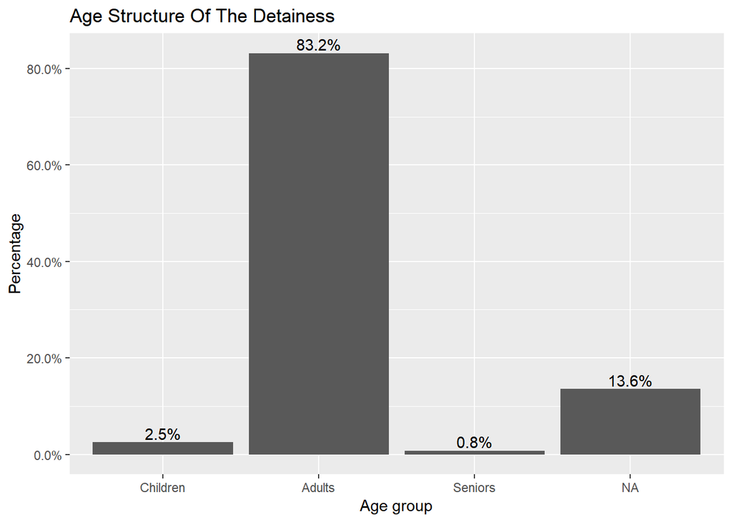

```r
library(ggplot2)
library(scales)
ggplot(data = dat, aes(x = tage)) + geom_bar(aes(y = (..count..)/sum(..count..))) +
  geom_text(aes(y = ((..count..)/sum(..count..)), label = scales::percent((..count..)/sum(..count..))),
            stat = "count", vjust = -0.25) +
  scale_y_continuous(labels = percent) +
  labs(title = "Age Structure Of The Detainess", y = "Percentage", x = "Age group")
```

Plot the nationalities of the detainees.

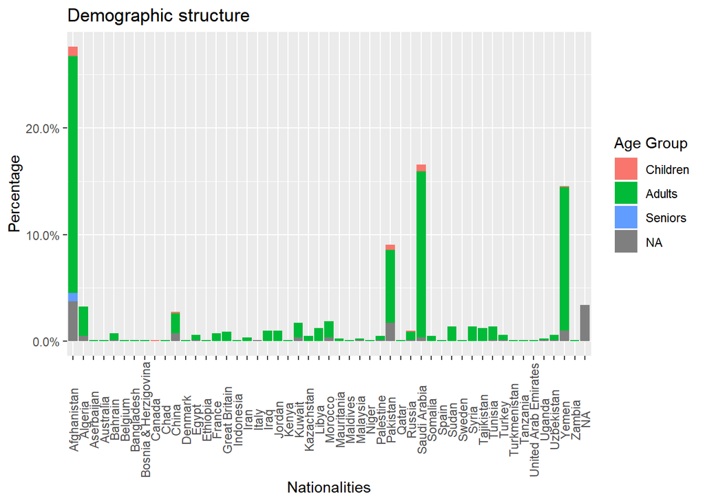

```r
ggplot(data = dat, aes(x = snat, fill = tage)) + geom_bar(aes(y = (..count..)/sum(..count..))) +
  scale_y_continuous(labels = percent) +
  labs(title = "Demographic structure", y = "Percentage", x = "Nationalities") +
  guides(fill = guide_legend('Age Group')) +
  theme(axis.text.x = element_text(angle = 90, hjust = 0.5, vjust = 0.5))
```

Using the *rworldmap* package, we can visulise the nationalities on a world map.

```r
library(rworldmap)
countries.dat = as.data.frame(table(dat$snat))
colnames(countries.dat) <- c("country", "value")
matched <- joinCountryData2Map(countries.dat, joinCode="NAME", nameJoinColumn="country")
```

```
## 47 codes from your data successfully matched countries in the map
## 3 codes from your data failed to match with a country code in the map
## 196 codes from the map weren't represented in your data
```

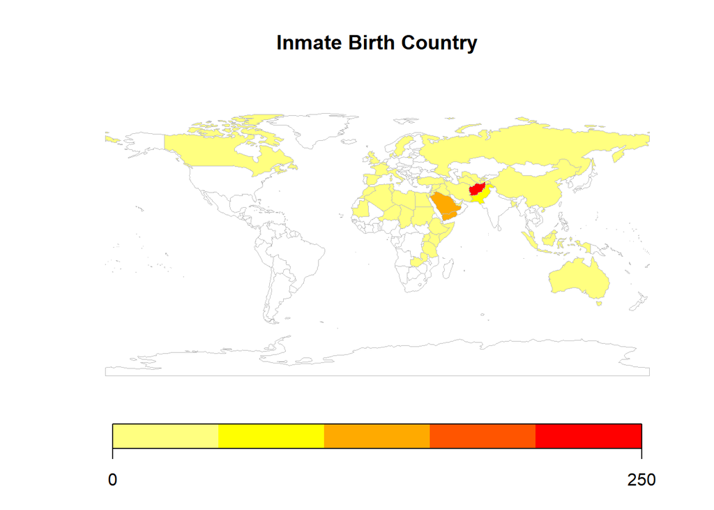

```r
mapCountryData(matched, nameColumnToPlot="value", mapTitle="Inmate Birth Country", catMethod = "pretty", colourPalette = "heat")
```

Plot the birth country of the detainees, so we can compare it to the nationalities.

```r
countries.dat = as.data.frame(table(dat$sbcountry))
colnames(countries.dat) <- c("country", "value")
matched <- joinCountryData2Map(countries.dat, joinCode="NAME", nameJoinColumn="country")
```

```
## 47 codes from your data successfully matched countries in the map
## 2 codes from your data failed to match with a country code in the map
## 196 codes from the map weren't represented in your data
```

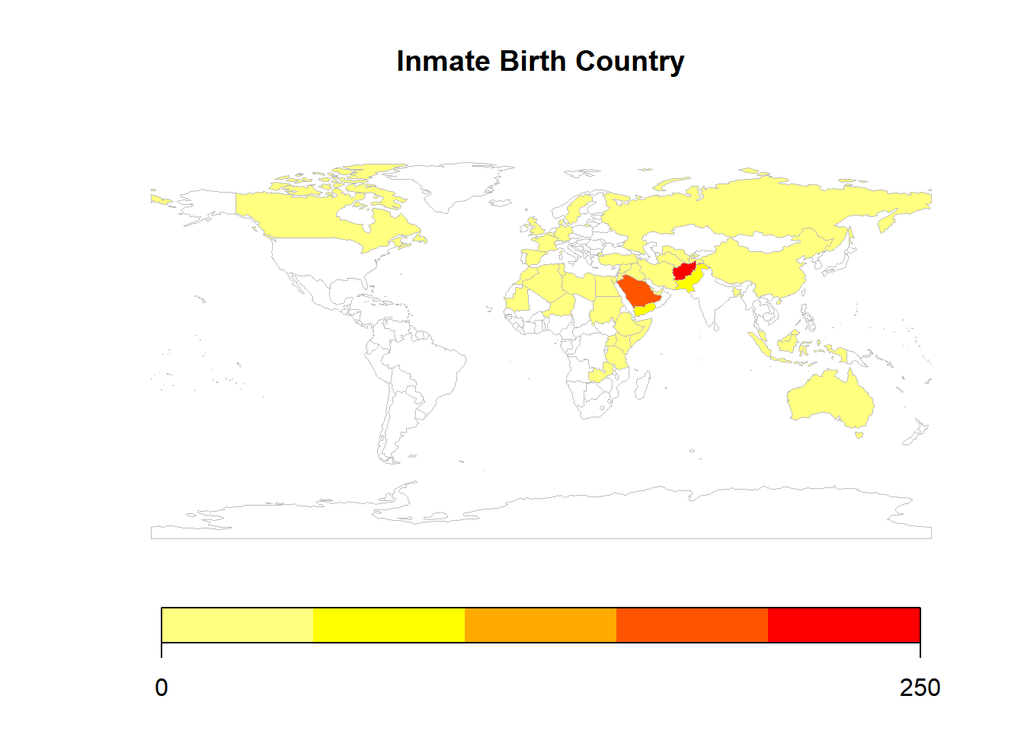

```r
mapCountryData(matched, nameColumnToPlot="value", mapTitle="Inmate Birth Country", catMethod = "pretty", colourPalette = "heat")
```

We can also see where the detainees were captured.

```r
countries.dat = as.data.frame(table(dat$sccountry))
colnames(countries.dat) <- c("country", "value")
matched <- joinCountryData2Map(countries.dat, joinCode="NAME", nameJoinColumn="country")
```

```
## 15 codes from your data successfully matched countries in the map
## 3 codes from your data failed to match with a country code in the map
## 228 codes from the map weren't represented in your data
```

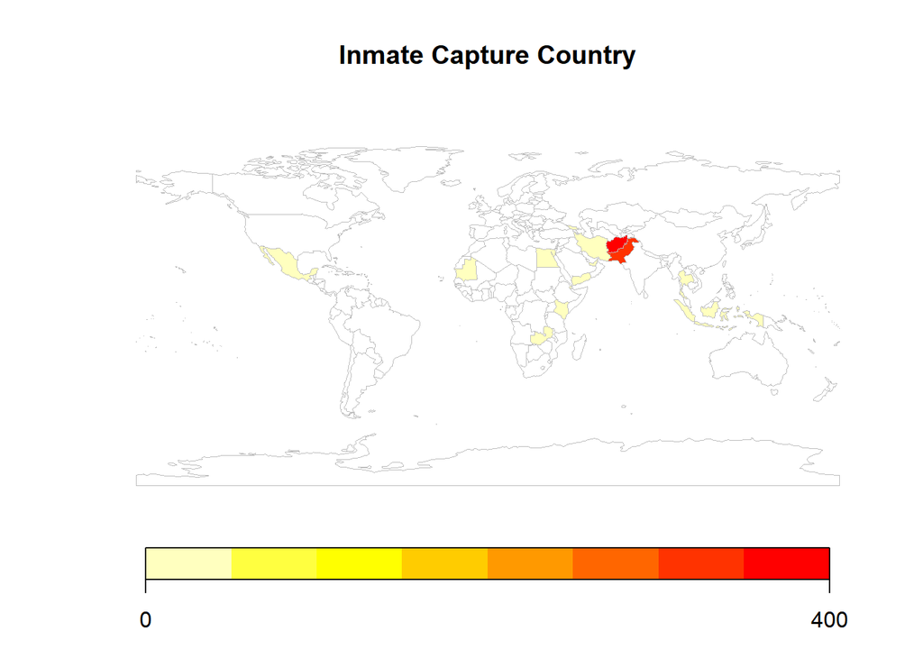

```r
mapCountryData(matched, nameColumnToPlot="value", mapTitle="Inmate Capture Country", catMethod = "pretty", colourPalette = "heat")
```

## Dealing with missing values

In the summary of the data, there are some missing values. Plot the missingness for each row of the data.

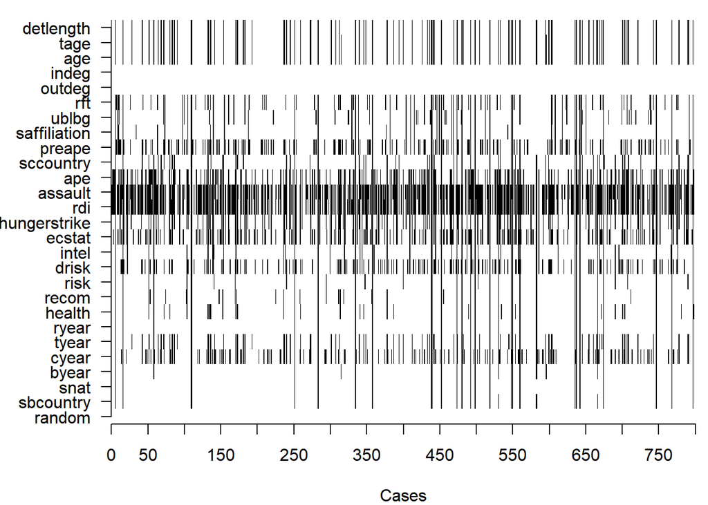

```r
par(mar=c(4, 5.5, 1, 0.6))
image(!is.na(dat), axes = FALSE, col = gray(0:1))
title(xlab = 'Cases')
axis(2, at = (0:(ncol(dat)-1))/(ncol(dat)-1), labels = names(dat), las =2)
axis(1, at = 50*(0:80)/800, 50*(0:80))
```

Plot the missing pattern for each variable as well.

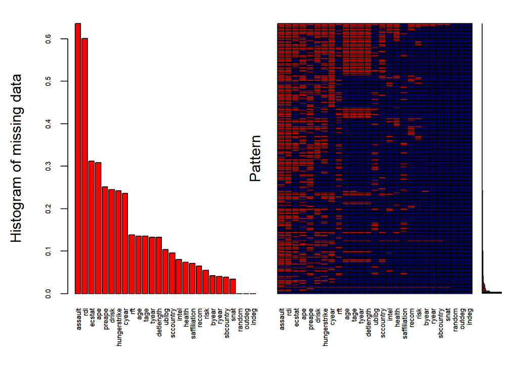

```
##
##  Variables sorted by number of missings:
##      Variable      Count
##       assault 0.63613551
##           rdi 0.60100376
##        ecstat 0.31242158
##           ape 0.30865747
##        preape 0.25094103
##         drisk 0.24466750
##  hungerstrike 0.24215809
##         cyear 0.23588457
##           rft 0.13801757
##           age 0.13550816
##          tage 0.13550816
##         tyear 0.13299875
##     detlength 0.13299875
##         ublbg 0.10414053
##     sccountry 0.09535759
##         intel 0.08030113
##        health 0.07402760
##  saffiliation 0.07151819
##         recom 0.06524467
##          risk 0.05520703
##         byear 0.04265997
##         ryear 0.04015056
##     sbcountry 0.03889586
##          snat 0.03387704
##        random 0.00000000
##        outdeg 0.00000000
##         indeg 0.00000000
```

```r
library(VIM)
aggr_plot = aggr(dat, col =c('navyblue','red'), numbers = TRUE , sortVars = TRUE ,
                 labels = names(dat), cex.axis =0.55, gap =1,
                 ylab =c("Histogram of missing data","Pattern"))
```

We decide to remove *rdi* and *assault* since they have over 60% data missing. We also decided to remove some variables with high correlations with other variables. We have removed: *ape*, *drisk*, *cyear* and *sbcountry*. We also removed *random* since it is meaningless

```r
dat$random = NULL
dat$rdi = NULL
dat$assault = NULL
dat$ape = NULL
dat$drisk = NULL
dat$cyear = NULL
dat$sbcountry = NULL
```

For some of the variables, we decide to do some imputations with the missing values.

```r
dat$ecstat[is.na(dat$ecstat)==TRUE] <- "Not clear"

dat$preape[is.na(dat$preape)==TRUE] <- 0

dat$hungerstrike[is.na(dat$hungerstrike)==TRUE]<- "No"

dat$rft[is.na(dat$rft)==TRUE] <- "No Recorded Reason"

dat$ublbg[is.na(dat$ublbg)==TRUE] <- "Low"

dat$health[is.na(dat$health)==TRUE]<-"Not bad health"

dat$saffiliation[is.na(dat$saffiliation)==TRUE]<- "No Affiliation"

dat$risk[is.na(dat$risk)==TRUE] <- "No"

dat$recom[is.na(dat$recom)==TRUE] <- "Stay"

dat$intel[is.na(dat$intel)==TRUE] <- "No Intel"
```

Take a look at the missing values pattern again

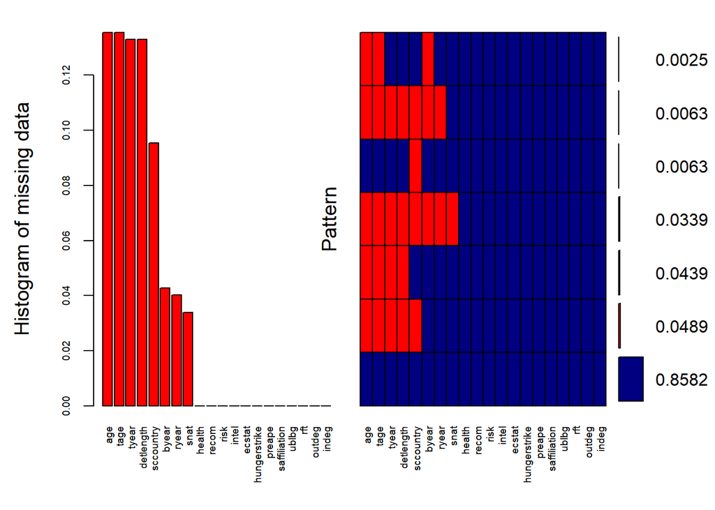

```
##
##  Variables sorted by number of missings:
##      Variable      Count
##           age 0.13550816
##          tage 0.13550816
##         tyear 0.13299875
##     detlength 0.13299875
##     sccountry 0.09535759
##         byear 0.04265997
##         ryear 0.04015056
##          snat 0.03387704
##        health 0.00000000
##         recom 0.00000000
##          risk 0.00000000
##         intel 0.00000000
##        ecstat 0.00000000
##  hungerstrike 0.00000000
##        preape 0.00000000
##  saffiliation 0.00000000
##         ublbg 0.00000000
##           rft 0.00000000
##        outdeg 0.00000000
##         indeg 0.00000000
```

```r
library(VIM)
aggr_plot = aggr(dat, col =c('navyblue','red'), numbers = TRUE , sortVars = TRUE ,
                 labels = names(dat), cex.axis =0.6, gap =1,
                 ylab =c("Histogram of missing data","Pattern"))
```

Omit the rest of the missing values

```r
newdat = na.omit(dat)
nrow(newdat)
```

```
## [1] 684
```

Create a new variable indicating whether detainess are collaborating or not. We will use this as our response.

```r
newdat$collab[newdat$outdeg >= 1 ] = 1
newdat$collab[newdat$outdeg == 0 ] = 0
newdat$collab = factor(newdat$collab,levels=0:1,labels=c("Non collaboration", "Collaboration"))
```

Some intuitive plots

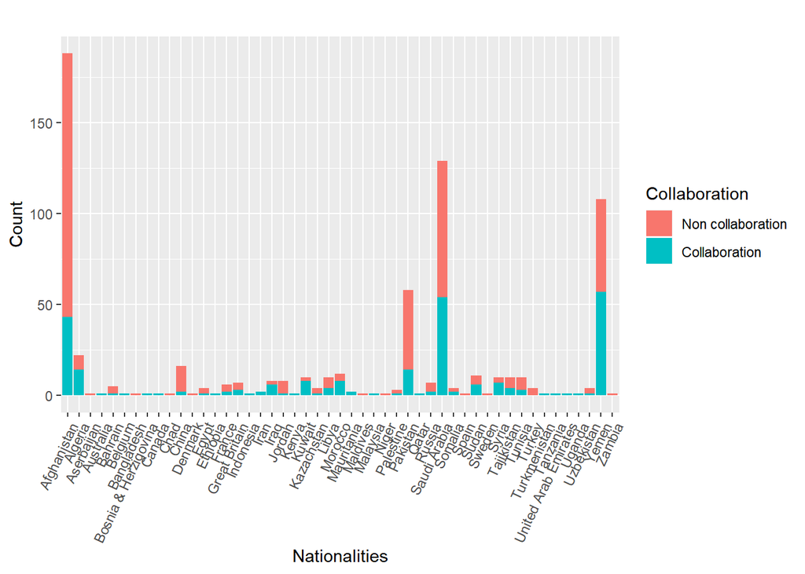

```r
library(grid)
library(gridExtra)

p = ggplot(data = newdat)

p1 = p +geom_bar(aes(x = snat, fill = collab)) +
theme(axis.text.x = element_text(angle = 65, hjust = 1))+
labs(title = "", y = "Count", x = "Nationalities") +
guides(fill = guide_legend('Collaboration'))

p2 = p +geom_bar(aes(x = ublbg, fill = collab)) +
labs(title = "", y = "Count", x = "Clossness to U.B.L.") +
guides(fill = guide_legend('Collaboration'))

p3 = p +geom_bar(aes(x = health, fill = collab)) +
  labs(title = "Histogram of Health", y = "Count", x = "Health") +
  guides(fill = guide_legend('Collaboration'))

p4 = p +geom_bar(aes(x = recom, fill = collab)) +
  labs(title = "", y = "Count", x = "Release Recommendation") +
  guides(fill = guide_legend('Collaboration'))

p5 = p +geom_bar(aes(x = risk, fill = collab)) +
  labs(title = "", y = "Count", x = "Assessed Future Threat Risk") +
  guides(fill = guide_legend('Collaboration'))

p6 = p +geom_bar(aes(x = intel, fill = collab)) +
  labs(title = "Histogram of Intel", y = "Count", x = "Assessed Intel Value") +
  guides(fill = guide_legend('Collaboration'))

p7 = p +geom_bar(aes(x = saffiliation, fill = collab)) +
  labs(title = "", y = "Count", x = "Terrorist Organization Affiliation") +
  guides(fill = guide_legend('Collaboration'))

p8 = p +geom_bar(aes(x = ecstat, fill = collab)) +
  labs(title = "", y = "Count", x = "Enemy Combatant Status") +
  guides(fill = guide_legend('Collaboration'))

p9 = p +geom_bar(aes(x = hungerstrike, fill = collab)) +
  labs(title = "", y = "Count", x = "Hunger Strike") +
  guides(fill = guide_legend('Collaboration'))

p10 = p +geom_bar(aes(x = indeg, fill = collab)) +
  labs(title = "", y = "Count", x = "Number of statements received") +
  guides(fill = guide_legend('Collaboration'))

p11 = p +geom_bar(aes(x = rft, fill = collab)) +
  theme(axis.text.x = element_text(angle = 65, hjust = 1)) +
  labs(title = "", y = "Count", x = "Reason for Transfer to GTMO") +
  guides(fill = guide_legend('Collaboration'))

p12 = p +geom_bar(aes(x = preape, fill = collab)) +
  labs(title = "", y = "Count", x = "Number of areas of potential exploitation") +
  guides(fill = guide_legend('Collaboration'))

p13 = p +geom_bar(aes(x = tage, fill = collab)) +
  labs(title = "", y = "Count", x = "Age Group") +
  guides(fill = guide_legend('Collaboration'))

p14 = p +geom_bar(aes(x = detlength, fill = collab)) +
  labs(title = "", y = "Count", x = "Lenth of Detention") +
  guides(fill = guide_legend('Collaboration'))

p1
```

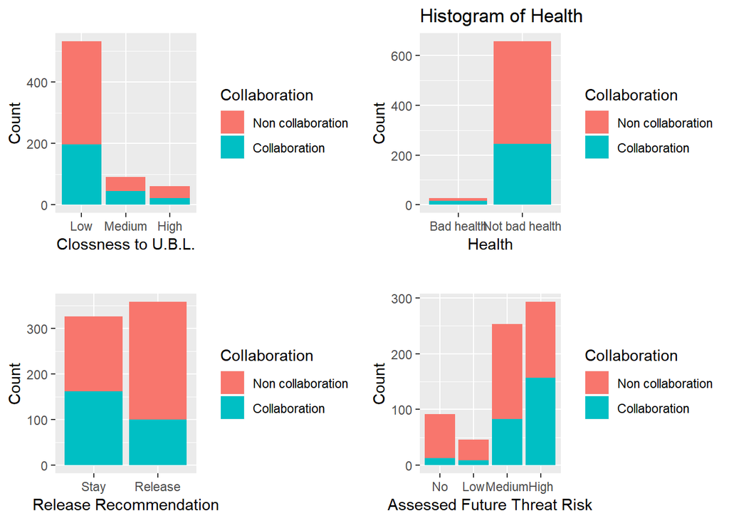

```r
grid.arrange(p2,p3,p4,p5, nrow=2, ncol=2)
```

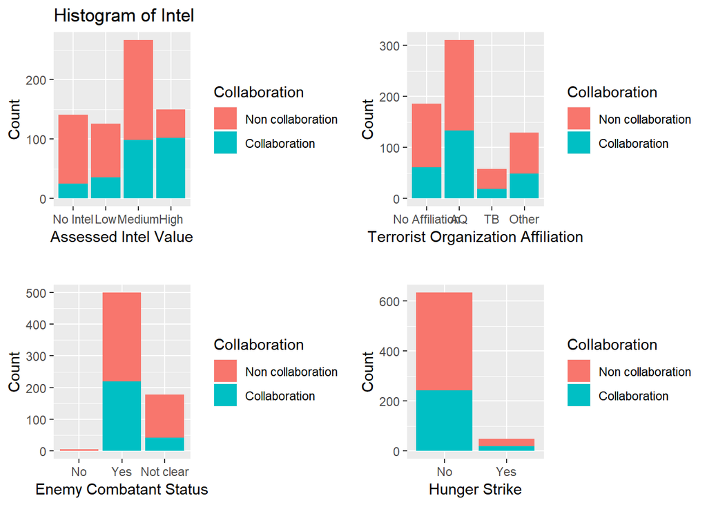

```r
grid.arrange(p6,p7,p8,p9, nrow=2, ncol=2)
```

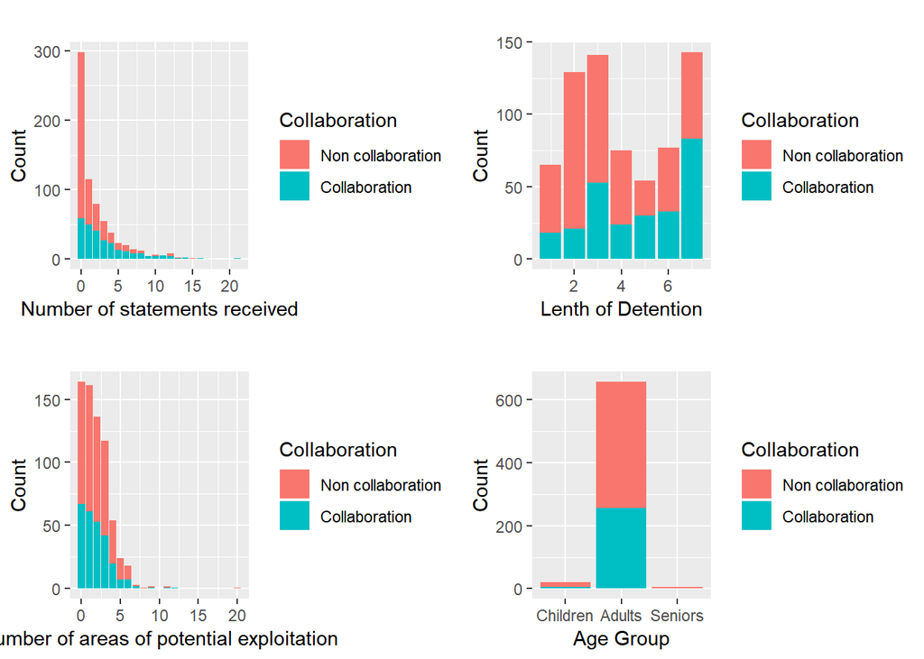

```r
grid.arrange(p10,p14,p12,p13, nrow=2, ncol=2)
```

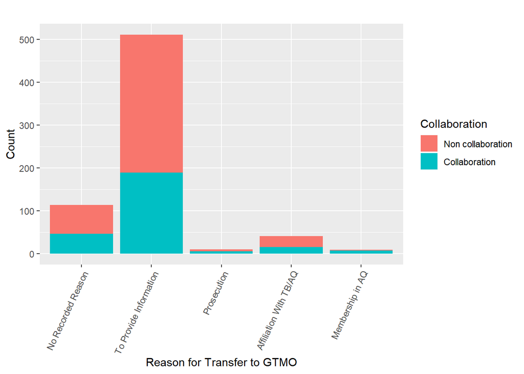

```r
p11
```

## Fitting the model

We use *collab* as our response and will not include *outdeg* in our model. Also, since *tage* is a combination of *tyear* and *byear*, we will not include *tyear* and *byear* in the model. *ryear* is not included for the same reason since we have *detlength*.

```r
fullmod = glm(collab ~ snat+health+recom+risk+intel+ecstat+hungerstrike+sccountry+preape+saffiliation+ublbg+rft+age+indeg+detlength,data = newdat, family = binomial)
```

Use the step function to reduce the model

```r
drop1(fullmod,test="Chisq")
```

```
## Single term deletions
##
## Model:
## collab ~ snat + health + recom + risk + intel + ecstat + hungerstrike +
##     sccountry + preape + saffiliation + ublbg + rft + age + indeg +
##     detlength
##              Df Deviance    AIC    LRT  Pr(>Chi)
## <none>            690.41 864.41
## snat         46   757.58 839.58 67.175 0.0224585 *
## health        1   695.81 867.81  5.403 0.0201032 *
## recom         1   693.74 865.74  3.327 0.0681485 .
## risk          3   692.25 860.25  1.844 0.6053846
## intel         3   710.95 878.95 20.541 0.0001311 ***
## ecstat        2   692.50 862.50  2.088 0.3521049
## hungerstrike  1   690.42 862.42  0.009 0.9228004
## sccountry    14   713.35 859.35 22.943 0.0611969 .
## preape        1   691.38 863.38  0.967 0.3253677
## saffiliation  3   693.84 861.84  3.435 0.3293377
## ublbg         2   692.47 862.47  2.066 0.3560078
## rft           4   694.41 860.41  3.997 0.4063795
## age           1   690.80 862.80  0.393 0.5306740
## indeg         1   693.62 865.62  3.210 0.0731909 .
## detlength     1   690.72 862.72  0.314 0.5751963
## ---
## Signif. codes:  0 '***' 0.001 '**' 0.01 '*' 0.05 '.' 0.1 ' ' 1
```

```r
stepmod = step(fullmod)
```

```
## Start:  AIC=864.41
## collab ~ snat + health + recom + risk + intel + ecstat + hungerstrike +
##     sccountry + preape + saffiliation + ublbg + rft + age + indeg +
##     detlength
##
##                Df Deviance    AIC
## - snat         46   757.58 839.58
## - sccountry    14   713.35 859.35
## - risk          3   692.25 860.25
## - rft           4   694.41 860.41
## - saffiliation  3   693.84 861.84
## - hungerstrike  1   690.42 862.42
## - ublbg         2   692.47 862.47
## - ecstat        2   692.50 862.50
## - detlength     1   690.72 862.72
## - age           1   690.80 862.80
## - preape        1   691.38 863.38
## <none>              690.41 864.41
## - indeg         1   693.62 865.62
## - recom         1   693.74 865.74
## - health        1   695.81 867.81
## - intel         3   710.95 878.95
##
## Step:  AIC=839.58
## collab ~ health + recom + risk + intel + ecstat + hungerstrike +
##     sccountry + preape + saffiliation + ublbg + rft + age + indeg +
##     detlength
##
##                Df Deviance    AIC
## - sccountry    16   783.85 833.85
## - saffiliation  3   760.49 836.49
## - rft           4   762.77 836.77
## - ecstat        2   759.35 837.35
## - hungerstrike  1   757.59 837.59
## - risk          3   762.48 838.48
## - preape        1   758.49 838.49
## - ublbg         2   760.64 838.64
## - detlength     1   759.03 839.03
## - recom         1   759.09 839.09
## <none>              757.58 839.58
```

[output cut: 140 more lines]

```
## <none>        796.64 818.64
## - age     1   799.57 819.57
## - health  1   803.13 823.13
## - indeg   1   806.73 826.73
## - intel   3   836.17 852.17
##
## Step:  AIC=817.45
## collab ~ health + intel + age + indeg
##
##          Df Deviance    AIC
## <none>        803.45 817.45
## - age     1   805.71 817.71
## - health  1   809.42 821.42
## - indeg   1   814.09 826.09
## - intel   3   842.33 850.33
```

```r
drop1(stepmod,test="Chisq")
```

```
## Single term deletions
##
## Model:
## collab ~ health + intel + age + indeg
##        Df Deviance    AIC    LRT  Pr(>Chi)
## <none>      803.45 817.45
## health  1   809.42 821.42  5.963   0.01461 *
## intel   3   842.33 850.33 38.875 1.845e-08 ***
## age     1   805.71 817.71  2.254   0.13328
## indeg   1   814.09 826.09 10.635   0.00111 **
## ---
## Signif. codes:  0 '***' 0.001 '**' 0.01 '*' 0.05 '.' 0.1 ' ' 1
```

```r
summary(stepmod)
```

```
##
## Call:
## glm(formula = collab ~ health + intel + age + indeg, family = binomial,
##     data = newdat)
##
## Deviance Residuals:
##     Min       1Q   Median       3Q      Max
## -2.0162  -0.8709  -0.6424   1.0380   1.9671
##
## Coefficients:
##                      Estimate Std. Error z value Pr(>|z|)
## (Intercept)          -0.07931    0.58920  -0.135  0.89293
## healthNot bad health -1.04342    0.43606  -2.393  0.01672 *
## intelLow              0.50146    0.29950   1.674  0.09407 .
## intelMedium           0.73788    0.26881   2.745  0.00605 **
## intelHigh             1.84520    0.32281   5.716 1.09e-08 ***
## age                  -0.01562    0.01058  -1.476  0.13989
## indeg                 0.11442    0.03646   3.138  0.00170 **
## ---
## Signif. codes:  0 '***' 0.001 '**' 0.01 '*' 0.05 '.' 0.1 ' ' 1
##
## (Dispersion parameter for binomial family taken to be 1)
##
##     Null deviance: 910.45  on 683  degrees of freedom
## Residual deviance: 803.45  on 677  degrees of freedom
## AIC: 817.45
##
## Number of Fisher Scoring iterations: 4
```

Create a model containing the interactions of the factor variables

```r
interactionmod = glm(collab ~ health:intel+health:indeg+health:age++intel:age+intel:indeg, data = newdat, family = binomial )
summary(interactionmod)
```

```
##
## Call:
## glm(formula = collab ~ health:intel + health:indeg + health:age +
##     +intel:age + intel:indeg, family = binomial, data = newdat)
##
## Deviance Residuals:
##     Min       1Q   Median       3Q      Max
## -1.8758  -0.8962  -0.6276   1.0170   2.3747
##
## Coefficients: (1 not defined because of singularities)
##                                      Estimate Std. Error z value Pr(>|z|)
## (Intercept)                           0.69289    0.82030   0.845   0.3983
## healthBad health:intelNo Intel       -8.76948 1455.40964  -0.006   0.9952
## healthNot bad health:intelNo Intel   -0.57317    1.28911  -0.445   0.6566
## healthBad health:intelLow            -0.54746    1.98507  -0.276   0.7827
## healthNot bad health:intelLow        -1.49420    1.15439  -1.294   0.1955
## healthBad health:intelMedium         -1.09756    2.13210  -0.515   0.6067
## healthNot bad health:intelMedium     -1.64866    0.99103  -1.664   0.0962
## healthBad health:intelHigh           14.70802  467.19667   0.031   0.9749
## healthNot bad health:intelHigh             NA         NA      NA       NA
## healthBad health:indeg                1.31301    0.58083   2.261   0.0238
## healthNot bad health:indeg            0.94472    0.42971   2.198   0.0279
## healthBad health:age                 -0.08415    0.06605  -1.274   0.2026
## healthNot bad health:age             -0.06852    0.03836  -1.786   0.0741
## intelLow:age                          0.04805    0.04680   1.027   0.3046
## intelMedium:age                       0.07490    0.04208   1.780   0.0751
## intelHigh:age                         0.05561    0.04534   1.227   0.2200
## intelLow:indeg                       -0.43521    0.46956  -0.927   0.3540
## intelMedium:indeg                    -0.84799    0.43333  -1.957   0.0504
## intelHigh:indeg                      -0.85610    0.43244  -1.980   0.0477
##
## (Intercept)
## healthBad health:intelNo Intel
## healthNot bad health:intelNo Intel
## healthBad health:intelLow
## healthNot bad health:intelLow
## healthBad health:intelMedium
## healthNot bad health:intelMedium   .
## healthBad health:intelHigh
## healthNot bad health:intelHigh
## healthBad health:indeg             *
## healthNot bad health:indeg         *
## healthBad health:age
## healthNot bad health:age           .
## intelLow:age
## intelMedium:age                    .
## intelHigh:age
## intelLow:indeg
## intelMedium:indeg                  .
## intelHigh:indeg                    *
## ---
## Signif. codes:  0 '***' 0.001 '**' 0.01 '*' 0.05 '.' 0.1 ' ' 1
##
## (Dispersion parameter for binomial family taken to be 1)
##
##     Null deviance: 910.45  on 683  degrees of freedom
## Residual deviance: 783.86  on 666  degrees of freedom
## AIC: 819.86
##
## Number of Fisher Scoring iterations: 14
```

```r
stepmod.add.interactionmod = update(stepmod, . ~ . +health:indeg+health:intel+health:age+intel:age+intel:indeg)
summary(stepmod.add.interactionmod)
```

```
##
## Call:
## glm(formula = collab ~ health + intel + age + indeg + health:indeg +
##     health:intel + health:age + intel:age + intel:indeg, family = binomial,
##     data = newdat)
##
## Deviance Residuals:
##     Min       1Q   Median       3Q      Max
## -1.8758  -0.8962  -0.6276   1.0170   2.3747
##
## Coefficients:
##                                    Estimate Std. Error z value Pr(>|z|)
## (Intercept)                        -8.07660 1455.40941  -0.006   0.9956
## healthNot bad health                8.19631 1455.40749   0.006   0.9955
## intelLow                            8.22203 1455.40594   0.006   0.9955
## intelMedium                         7.67193 1455.40512   0.005   0.9958
## intelHigh                          23.47751 1528.54971   0.015   0.9877
## age                                -0.08415    0.06605  -1.274   0.2026
## indeg                               1.31301    0.58083   2.261   0.0238 *
## healthNot bad health:indeg         -0.36830    0.39079  -0.942   0.3460
## healthNot bad health:intelLow      -9.14305 1455.40386  -0.006   0.9950
## healthNot bad health:intelMedium   -8.74742 1455.40275  -0.006   0.9952
## healthNot bad health:intelHigh    -22.90433 1528.54753  -0.015   0.9880
## healthNot bad health:age            0.01563    0.05377   0.291   0.7712
## intelLow:age                        0.04805    0.04680   1.027   0.3046
## intelMedium:age                     0.07490    0.04208   1.780   0.0751 .
## intelHigh:age                       0.05561    0.04534   1.227   0.2200
## intelLow:indeg                     -0.43521    0.46956  -0.927   0.3540
## intelMedium:indeg                  -0.84799    0.43333  -1.957   0.0504 .
## intelHigh:indeg                    -0.85610    0.43244  -1.980   0.0477 *
## ---
## Signif. codes:  0 '***' 0.001 '**' 0.01 '*' 0.05 '.' 0.1 ' ' 1
##
## (Dispersion parameter for binomial family taken to be 1)
##
##     Null deviance: 910.45  on 683  degrees of freedom
## Residual deviance: 783.86  on 666  degrees of freedom
## AIC: 819.86
##
## Number of Fisher Scoring iterations: 14
```

Reduce this model further

```r
stepmod.add.interactionmod.step = step(stepmod.add.interactionmod)
```

```
## Start:  AIC=819.86
## collab ~ health + intel + age + indeg + health:indeg + health:intel +
##     health:age + intel:age + intel:indeg
##
##                Df Deviance    AIC
## - health:intel  3   786.39 816.39
## - intel:age     3   787.67 817.67
## - health:age    1   783.94 817.94
## - health:indeg  1   784.95 818.95
## <none>              783.86 819.86
## - intel:indeg   3   792.92 822.92
##
## Step:  AIC=816.39
## collab ~ health + intel + age + indeg + health:indeg + health:age +
##     intel:age + intel:indeg
##
##                Df Deviance    AIC
## - intel:age     3   790.35 814.35
## - health:age    1   786.41 814.41
## <none>              786.39 816.39
## - health:indeg  1   789.15 817.15
## - intel:indeg   3   795.40 819.40
##
## Step:  AIC=814.35
## collab ~ health + intel + age + indeg + health:indeg + health:age +
##     intel:indeg
##
##                Df Deviance    AIC
## - health:age    1   790.39 812.39
## <none>              790.35 814.35
## - health:indeg  1   792.98 814.98
## - intel:indeg   3   800.56 818.56
##
## Step:  AIC=812.39
## collab ~ health + intel + age + indeg + health:indeg + intel:indeg
##
##                Df Deviance    AIC
## - age           1   791.67 811.67
## <none>              790.39 812.39
## - health:indeg  1   793.00 813.00
## - intel:indeg   3   800.64 816.64
##
## Step:  AIC=811.67
## collab ~ health + intel + indeg + health:indeg + intel:indeg
##
##                Df Deviance    AIC
## <none>              791.67 811.67
## - health:indeg  1   794.56 812.56
## - intel:indeg   3   802.50 816.50
```

```r
drop1(stepmod.add.interactionmod.step, test="Chisq")
```

```
## Single term deletions
##
## Model:
## collab ~ health + intel + indeg + health:indeg + intel:indeg
##              Df Deviance    AIC     LRT Pr(>Chi)
## <none>            791.67 811.67
## health:indeg  1   794.56 812.56  2.8943  0.08889 .
## intel:indeg   3   802.50 816.50 10.8291  0.01269 *
## ---
## Signif. codes:  0 '***' 0.001 '**' 0.01 '*' 0.05 '.' 0.1 ' ' 1
```

```r
summary(stepmod.add.interactionmod.step)
```

```
##
## Call:
## glm(formula = collab ~ health + intel + indeg + health:indeg +
##     intel:indeg, family = binomial, data = newdat)
##
## Deviance Residuals:
##     Min       1Q   Median       3Q      Max
## -2.0321  -0.9028  -0.5809   0.9843   1.9302
##
## Coefficients:
##                            Estimate Std. Error z value Pr(>|z|)
## (Intercept)                 -1.3944     0.6608  -2.110  0.03485 *
## healthNot bad health        -0.2997     0.6218  -0.482  0.62982
## intelLow                     0.3118     0.3523   0.885  0.37604
## intelMedium                  0.9134     0.2979   3.066  0.00217 **
## intelHigh                    2.0172     0.3571   5.649 1.61e-08 ***
## indeg                        1.5412     0.5758   2.677  0.00743 **
## healthNot bad health:indeg  -0.5088     0.3711  -1.371  0.17036
## intelLow:indeg              -0.4971     0.4794  -1.037  0.29978
## intelMedium:indeg           -0.9387     0.4452  -2.109  0.03498 *
## intelHigh:indeg             -0.9467     0.4445  -2.130  0.03320 *
## ---
## Signif. codes:  0 '***' 0.001 '**' 0.01 '*' 0.05 '.' 0.1 ' ' 1
##
## (Dispersion parameter for binomial family taken to be 1)
##
##     Null deviance: 910.45  on 683  degrees of freedom
## Residual deviance: 791.67  on 674  degrees of freedom
## AIC: 811.67
##
## Number of Fisher Scoring iterations: 5
```

Predict whether an inmate will collaborate or not using the model without interaction terms

```r
prediction = predict(stepmod, newdat)

for (i in 1:nrow(newdat))
{
  if (prediction[i] >= 1)
  {
    prediction[i] = 1
  }
  else
  {
    prediction[i] = 0
  }
}
prediction = factor(prediction, levels = 0:1, labels = c("Non collaboration", "Collaboration"))
```

Compare this prediction to actual data

```r
count = 0
for (i in 1:nrow(newdat)){
  if (prediction[i] == newdat$collab[i]){
    count = count + 1
  }
}
count
```

```
## [1] 452
```

Correctly predicted 452 inmate’s collaboration out of 684 cases

Predict whether an inmate will collaborate or not using the model with interaction terms

```r
prediction = predict(stepmod.add.interactionmod.step, newdat)

for (i in 1:nrow(newdat))
{
  if (prediction[i] >= 1)
  {
    prediction[i] = 1
  }
  else
  {
    prediction[i] = 0
  }
}
prediction = factor(prediction, levels = 0:1, labels = c("Non collaboration", "Collaboration"))
count = 0
for (i in 1:nrow(newdat)){
  if (prediction[i] == newdat$collab[i]){
    count = count + 1
  }
}
count
```

```
## [1] 448
```

Correctly predicted 448 inmate’s collaboration out of 684 cases

We will use the simplest model to explain the relationship of *collab* with other variables.

Plot the model coefficients

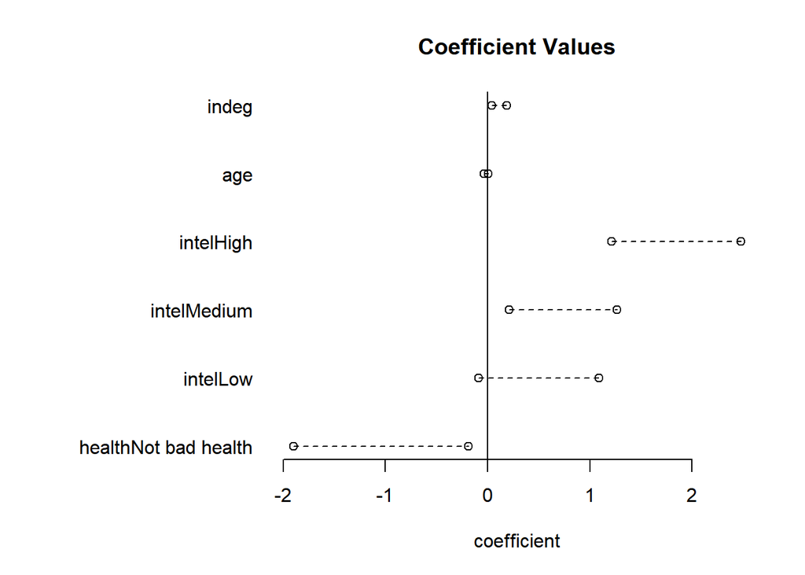

```r
par(mar=c(5,12,4,2))
CI.lower<-summary(stepmod)$coefficients[,1]-1.96*summary(stepmod)$coefficients[,2]
CI.upper<-summary(stepmod)$coefficients[,1]+1.96*summary(stepmod)$coefficients[,2]
CI<-cbind(CI.lower,CI.upper)[-1,]
matplot(CI, cbind(1:dim(CI)[1],1:dim(CI)[1]),pch=1,col=1,lty=2,ylab="",xlab="coefficient",axes=F)
abline(v=0)
segments(x0=CI[,1], y0=1:dim(CI)[1],x1=CI[,2], y1=1:dim(CI)[1],lty=2)
axis(1)
par(las=2)
axis(2,at=1:dim(CI)[1],labels=rownames(CI),tick=F)
title(main = "Coefficient Values")
```

Plots for interpretation

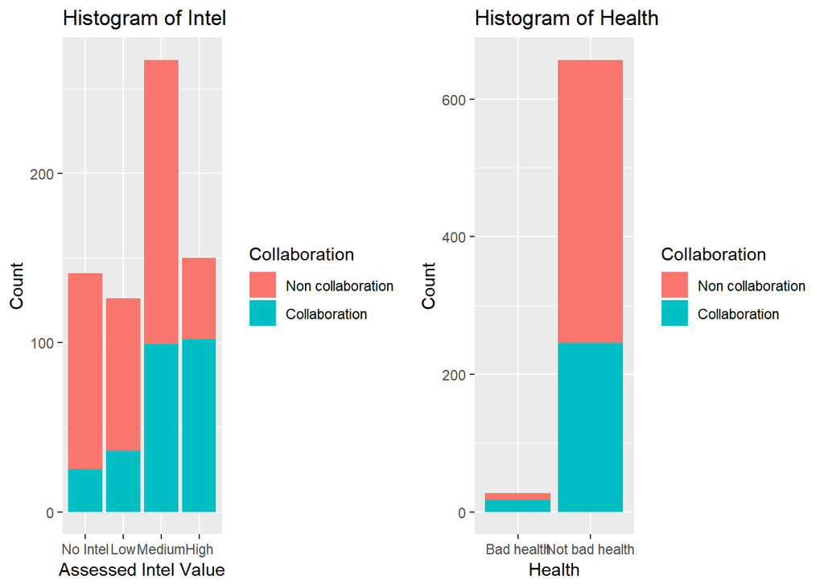

```r
grid.arrange(p6,p3, nrow=1, ncol=2)
```